# Cheat Sheet

2026-01-25

```r
library(MASS)
library(expm)
```

# Disegnare tabella probabilità

$$\begin{array}{c|cc}
& y=1 & y=2 \\
\hline
p_{Y|X}(y|0) & 0.5 & 0.5 \\
p_{Y|X}(y|1) & 0.1 & 0.9 \\
p_{Y|X}(y|2) & 0.4 & 0.6
\end{array}$$

# Integrali in R

integrate ( f, low, up )

nel caso di improprio, si scrive `Inf` esempio:

```r
integrate(function(x) {1/x^2}, lower = 1, upper = Inf)
```

```
## 1 with absolute error < 1.1e-14
```

# matrici in generale

define the Matrix

```r
P <- matrix(c(0.4, 0.6,
              0.6, 0.4), nrow = 2, byrow = TRUE)
```

compute the product:

```r
P2 <- P %*% P   # sì, il prodotto comprende i %
```

3. altre cose: *: Element-by-element multiplication solve(A): Finds the inverse matrix (A−1). t(A): Transposes the matrix.

```r
P_steady <- P
for(i in 1:10000) { P_steady <- P_steady %*% P }
print(P_steady)
```

```
##      [,1] [,2]
## [1,]  0.5  0.5
## [2,]  0.5  0.5
```

per calcolare time dependent probability (e^Gt):

```r
# 1. Define the Rate Matrix Q
Q <- matrix(c(-3,  2,  1,
               4, -5,  1,
               1,  0, -1), nrow=3, byrow=TRUE)

# 2. Define the time t
t <- 2.5

# 3. Calculate P(t) = e^(Qt)
# proportional to probability of transition over time t
P_t <- expm(Q * t)
print(P_t)
```

```
##           [,1]      [,2]     [,3]
## [1,] 0.3591642 0.1442047 0.496631
## [2,] 0.3591642 0.1442047 0.496631
## [3,] 0.3551215 0.1415096 0.503369
```

The output P_t is a probability matrix (rows sum to 1) -> Entry [1, 2]: The probability that you are in State 2 at time t=2.5, given that you started in State 1. Row 1: The full probability distribution at time t=2.5 if you started in State 1.

# CTMC SOLVER DATA: GET P FROM G(Q) e stato pi0

Dato il vettore dello stato di partenza e la matrice di generazione, Calcola la matrice di probabilità di transizione P(t) e la distribuzione finale π(t).

Devi usare questo script quando nell’esercizio trovi domande di questo tipo: 1. Ti chiedono cosa succede in un tempo specifico e finito (es. “Qual è la probabilità che il server sia rotto dopo 2.5 ore?”). Nota: Se ti chiedono “a lungo termine” o “steady state”, questa funzione va bene solo se metti un t enorme (es. 1000) 2. Partenza Incerta: Quando il testo dice “All’inizio, c’è il 50% di probabilità che il sistema sia già guasto”. Qui il vettore pi0 non sarà solo c(1, 0, 0) ma c(0.5, 0.5, 0), e questa funzione gestisce automaticamente quella media ponderata.

```r
get_state_probability <- function(Q, pi0, t) {

  P_t <- expm(Q * t)
  pi_t <- pi0 %*% P_t

  return(list(
    "Transition_Matrix_Pt" = P_t,
    "Final_Distribution_pi_t" = pi_t
  ))
}
number_row <- 3
Q <- matrix(c(-0.3,  0.2,  0.1,
               0.0, -0.5,  0.5,
               1.0,  0.0, -1.0),
            nrow = number_row, byrow = TRUE)
pi0 <- c(0.5, 0.5, 0.0)
time <- 2.0
results <- get_state_probability(Q, pi0, time)

# Print the results nicely
print("--- THE TRANSITION MATRIX P(t) ---")
```

```
## [1] "--- THE TRANSITION MATRIX P(t) ---"
```

```r
print("This shows the probabilities for ALL possible starting states:")
```

```
## [1] "This shows the probabilities for ALL possible starting states:"
```

```r
print(results$Transition_Matrix_Pt)
```

```
##           [,1]      [,2]      [,3]
## [1,] 0.6736456 0.1956840 0.1306704
## [2,] 0.3282840 0.4123048 0.2594112
## [3,] 0.6501361 0.1313136 0.2185503
```

```r
print("--- THE FINAL DISTRIBUTION pi(t) ---")
```

```
## [1] "--- THE FINAL DISTRIBUTION pi(t) ---"
```

```r
print("This is the specific probability for YOUR uncertain start:")
```

```
## [1] "This is the specific probability for YOUR uncertain start:"
```

```r
print(results$Final_Distribution_pi_t)
```

```
##           [,1]      [,2]      [,3]
## [1,] 0.5009648 0.3039944 0.1950408
```

# GET Q FROM holding times and probability

```r
get_Q_matrix <- function(holding_times, P_embedded) {

     rates <- 1 / holding_times
     Lambda <- diag(rates)

     # Apply the Formula: Q = Lambda * (P - I)
     I <- diag(nrow(P_embedded))
     Q <- Lambda %*% (P_embedded - I)

     rownames(Q) <- rownames(P_embedded)
     colnames(Q) <- colnames(P_embedded)

     return(Q)
}

number_row = 3

# avg_times: Vector of average times spent in each state
avg_times <- c(3, 6, 12)

# P_embedded: The embedded transition matrix (probabilities of where to go next)
P_embedded <- matrix(c(0,   1/2, 1/2,
                       3/4, 0,   1/4,
                       1/4, 3/4, 0),
                     nrow=number_row, byrow=TRUE)

# Label them for nicer output
states <- c("Rain", "Snow", "Clear")
rownames(P_embedded) <- states
colnames(P_embedded) <- states

# 2. Call the function
Q_result <- get_Q_matrix(avg_times, P_embedded)

# 3. Print the result (in fractions for easier checking)
print(fractions(Q_result))
```

```
##       Rain  Snow  Clear
## Rain   -1/3   1/6   1/6
## Snow    1/8  -1/6  1/24
## Clear  1/48  1/16 -1/12
```

# GET EMBEDDED P FROM Q

```r
get_embedded_P <- function(Q) {
  P_emb <- Q * 0 # Crea matrice di zeri della stessa dimensione
  n <- nrow(Q)

  for (i in 1:n) {
    # Il rate totale di uscita è l'elemento diagonale (con segno opposto)
    rate_out <- -Q[i, i]

    # Se rate_out è 0 (stato assorbente), metti 1 sulla diagonale per convenzione
    if (rate_out == 0) {
      P_emb[i, i] <- 1
    } else {
      P_emb[i, ] <- Q[i, ] / rate_out
      P_emb[i, i] <- 0
    }
  }
  return(P_emb)
}

P_jump <- get_embedded_P(Q)
print(P_jump)
```

```
##      [,1]      [,2]      [,3]
## [1,]    0 0.6666667 0.3333333
## [2,]    0 0.0000000 1.0000000
## [3,]    1 0.0000000 0.0000000
```

# USEFUL LATEX

**Some useful LaTeX commands for writing formulas**

Inline formulas : $\sin(\pi x)$

Formulas in a separate line:
$$\sin(\pi x)$$

Set operations:
$$A \cap B, A\cup B, \bar{A}=\Omega\setminus A$$
Mean and variance:
$$\mu_X, E[X],\bar{X}, \bar{x}, \sigma^2, Var[X]$$
Fractions:
$$\frac{1}{\sqrt{2}} X_i, \frac{X_i}{Y_i}$$

Sums:
$$\sum_{i=1}^n X_i, \sum_{i=1}^n \log X_i, \sum_{i=1}^n \sqrt{X_i},
\sum_{i=1}^n \frac{X_i}{Y_i}$$
Integrals:
$$\int_{0}^1 f(x) dx, \int_{a}^{\infty} f(x) dx, \int_{-\infty}^{\infty}
f(x) dx$$

Matrices:
$$\mathbf
G=\left[\begin{array}{ccc}
-4 & 2 & 2\\
1 & -2 & 1\\
0.5 & 1 & -1.5\end{array}
\right]$$

**Code chunks and R commands**

```r
2 * 3 / log(1.2)
```

```
## [1] 32.90889
```

```r
sin(2 * pi / 20)
```

```
## [1] 0.309017
```

```r
a <- 2 * c(1, 2)
a
```

```
## [1] 2 4
```

```r
p <- pnorm(0.95)
p
```

```
## [1] 0.8289439
```

```r
G <- matrix(c(-4, 2, 2, 1, -2, 1, 0.5, 1, -1.5),ncol=3, byrow=T)
G
```

```
##      [,1] [,2] [,3]
## [1,] -4.0    2  2.0
## [2,]  1.0   -2  1.0
## [3,]  0.5    1 -1.5
```

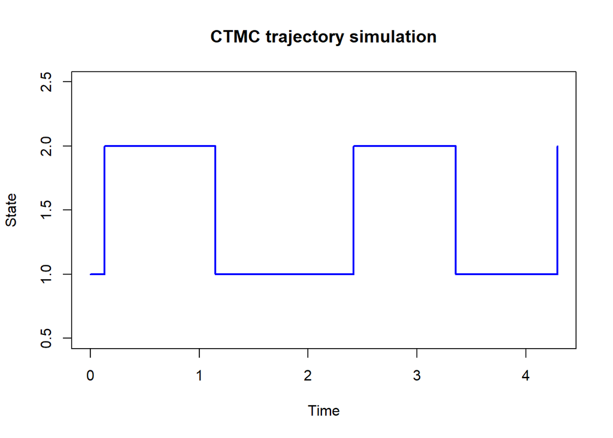

```r
simulate_ctmc_path <- function(G, start_state, n_jumps) {

  current_time  <- 0
  current_state <- start_state
  time_history  <- c(current_time)
  state_history <- c(current_state)

  for (i in 1:n_jumps) {

    lambda <- -G[current_state, current_state]
    hold_time <- rexp(1, rate = lambda)

    probs <- pmax(G[current_state, ], 0)
    probs <- probs / sum(probs)

    next_state <- sample(1:ncol(G), size=1, prob=probs)

    current_time  <- current_time + hold_time
    current_state <- next_state

    time_history  <- c(time_history, current_time)
    state_history <- c(state_history, current_state)
  }

  plot(time_history, state_history, type="s",
       main="CTMC trajectory simulation",
       xlab="Time", ylab="State", ylim=c(0.5, ncol(G)+0.5),
       col="blue", lwd=2)

  return(data.frame(Time=time_history, State=state_history))
}

# --- ESEMPIO DI UTILIZZO ---

# Definiamo una matrice G
# Stato 1 -> Stato 2 con rate 2
# Stato 2 -> Stato 1 con rate 1
G_example <- matrix(c(-2,  2,
                       1, -1),
                    nrow=2, byrow=TRUE)

# Simula 5 salti partendo dallo stato 1
simulazione <- simulate_ctmc_path(G_example, start_state=1, n_jumps=5)
```

```r
print(simulazione)
```

```
##        Time State
## 1 0.0000000     1
## 2 0.1307327     2
## 3 1.1493122     1
## 4 2.4167255     2
## 5 3.3545787     1
## 6 4.2894819     2
```